# liberalization

#### 1991 Liberalization - 30 since - Manmohan Singh.

Currency devaluation Delicensing Open to foreign trade

Data Visualization:

> Timeline of 30 years since liberalization

> Team of bureaucrats along with PV Narsimha Rao

> Research papers - events of 1991

> Data Viz - key variables - 10-15 visuals that tell the story of liberalization

> Macroeconomic variables - GDP, FDI Market Cap of companies No. of STD Booths Development indicators Fiscal spending GDP growth rate Novel variables that reflect the effects of Liberalization

> Explore State wise variations - GIS Launch - 1st and 2nd week July Development Data Lab - Aditi Bhoumik 900 page volume

> Macro Economic Indicator

> M1 Supply, money supply

> Earnings and wages

> Income per capita

### Money Supply in Economy

|  | Years | M1_Supply | Exchange rate | USD |
| --- | --- | --- | --- | --- |
| 20 | 1999 | 12610319453226.39 | 43.06 | 292867165143.28 |
| 5 | 1984 | 1406286627313.44 | 11.35 | 123939906448.27 |
| 36 | 2015 | 94385324427760.50 | 64.13 | 1471781402538.41 |
| 26 | 2005 | 27612779569338.41 | 44.05 | 626833601278.58 |
| 21 | 2000 | 14036968778863.12 | 44.94 | 312361188401.76 |

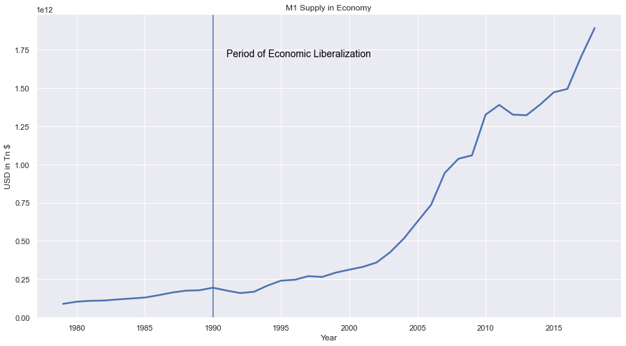

M1 money supply includes sum of currency available to Households and Businesses to make payments. US currencies and balances in checking and savings account are part of M1 calculations.

Marcoeconomic theory suggests that increase in money circulation leads to lower interest rates and higher borrowing / lending and consumer spending in the economy.

### Rate of Inflation

|  | Year | Rate |
| --- | --- | --- |
| 25 | 2011 | 9.50 |
| 29 | 2015 | 4.90 |
| 32 | 2018 | 3.43 |
| 16 | 2002 | 3.98 |
| 28 | 2014 | 5.80 |

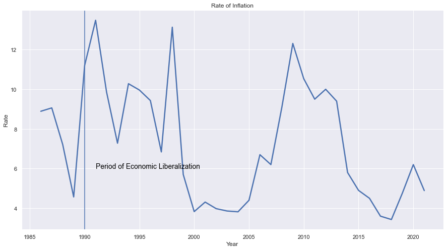

### Trade - Imports and Exports

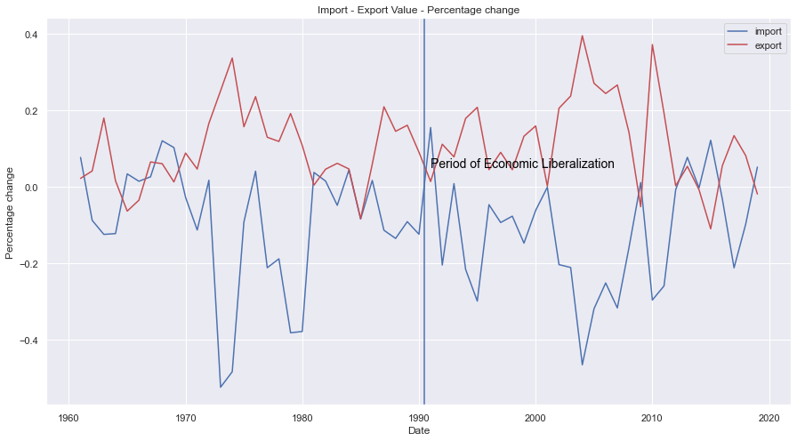

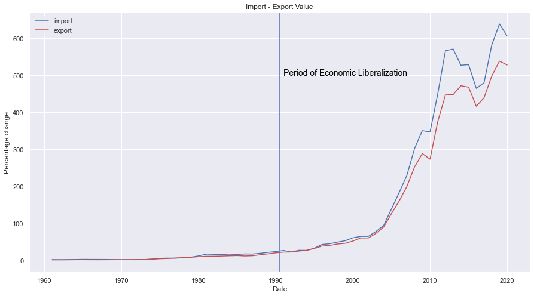

### GDP Per Capita

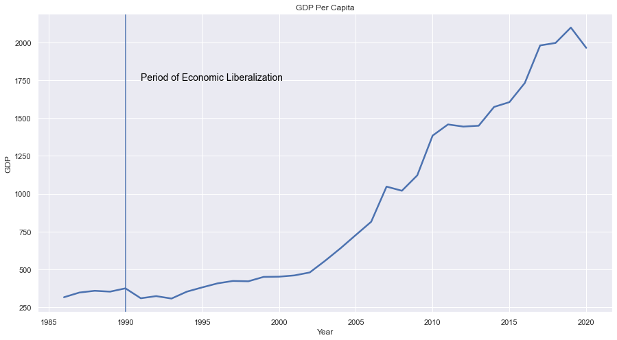

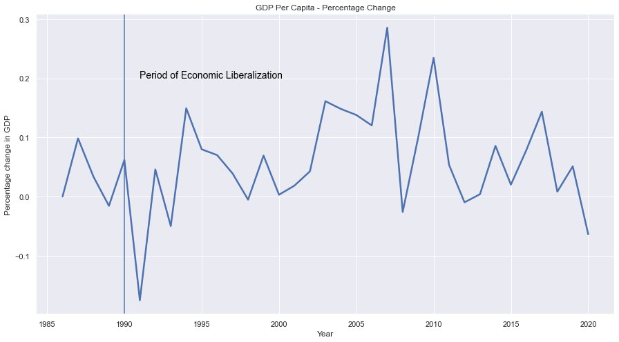

### India Foreign Direct Investment

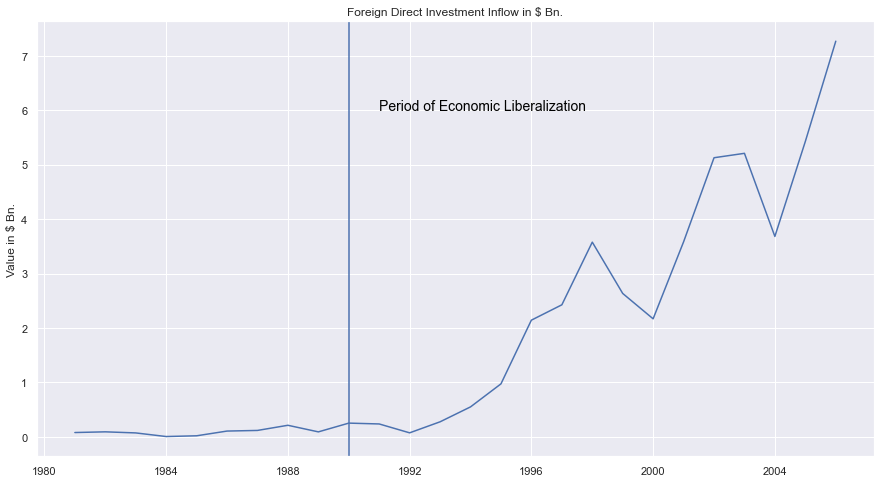

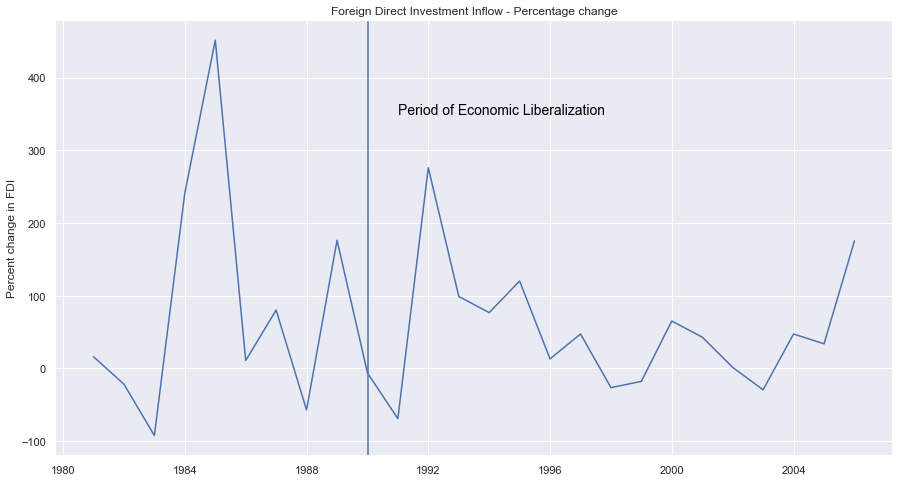

### S&P BSE Stock Market Index

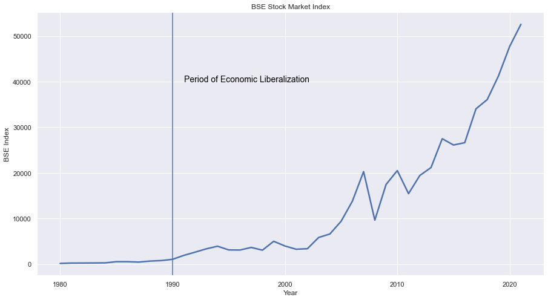

### Access to Electricity

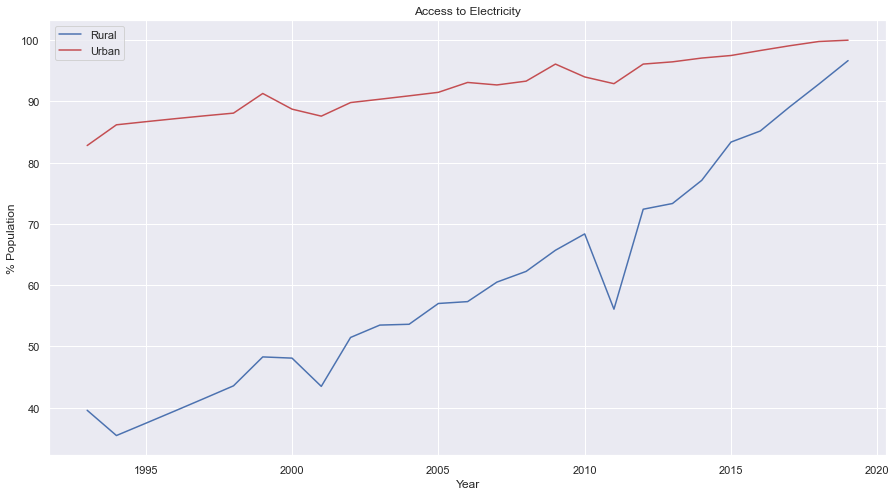

### Exchange rate USD/INR

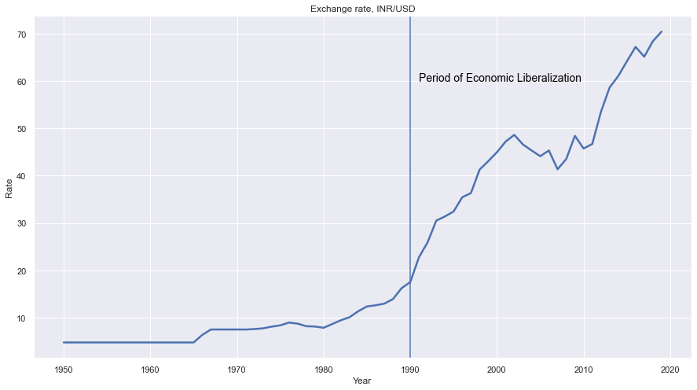

### Income Inequality

|  | Percentile | Label | Year | Pre-tax national income |
| --- | --- | --- | --- | --- |
| 152 | p50p90 | Middle 40% | 1965 | 92.05 |
| 50 | p90p100 | Top 10% | 2001 | 129.76 |
| 22 | p90p100 | Top 10% | 1973 | 108.13 |
| 188 | p50p90 | Middle 40% | 2001 | 85.87 |
| 67 | p90p100 | Top 10% | 2018 | 176.55 |

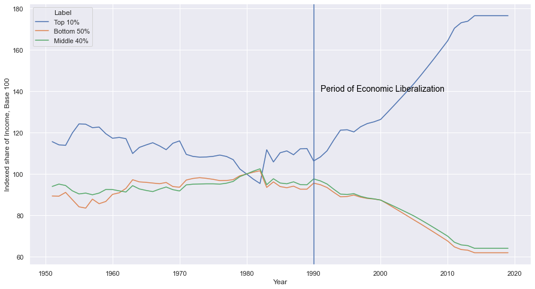

The effect of high growth contributed to income inequality as those in the 90th percentile were in the best position to obtain the benefits on liberalized policies.

### Explore statewise variations - Literacy

|  | State | pc91_lit_share | pc91_mlit_share | pc91_flit_share | pc01_lit_share | pc01_mlit_share | pc01_flit_share |
| --- | --- | --- | --- | --- | --- | --- | --- |
| 19 | Mizoram | 0.53 | 0.59 | 0.48 | 0.62 | 0.66 | 0.57 |
| 2 | Telengana | 0.24 | 0.33 | 0.15 | 0.41 | 0.50 | 0.32 |
| 29 | West Bengal | 0.41 | 0.52 | 0.31 | 0.53 | 0.62 | 0.43 |
| 30 | Jammu and Kashmir | 0.00 | 0.00 | 0.00 | 0.00 | 0.00 | 0.00 |
| 14 | Madhya Pradesh | 0.25 | 0.36 | 0.13 | 0.46 | 0.57 | 0.34 |

|  | State_Name | geometry |
| --- | --- | --- |
| 14 | Chhattishgarh | POLYGON ((9275926.808 2765881.317, 9276185.437... |
| 5 | Jharkhand | POLYGON ((9762288.285 2772949.712, 9762301.816... |
| 19 | Himachal Pradesh | POLYGON ((8548682.698 3929291.879, 8548760.706... |
| 36 | Jammu and Kashmir | POLYGON ((8550375.654 3927668.327, 8550332.102... |
| 35 | Ladakh | POLYGON ((8550375.654 3927668.327, 8548619.625... |

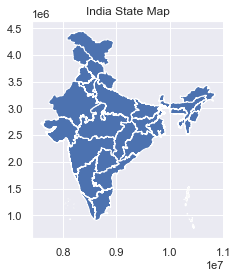

|  | State_Name | geometry | State | pc91_lit_share | pc91_mlit_share | pc91_flit_share | pc01_lit_share | pc01_mlit_share | pc01_flit_share |
| --- | --- | --- | --- | --- | --- | --- | --- | --- | --- |
| 30 | Ladakh | POLYGON ((8550375.654 3927668.327, 8548619.625... | Ladakh | 0.00 | 0.00 | 0.00 | 0.00 | 0.00 | 0.00 |
| 7 | Maharashtra | MULTIPOLYGON (((8280974.863 2515416.345, 82809... | Maharashtra | 0.42 | 0.53 | 0.30 | 0.57 | 0.67 | 0.47 |
| 28 | West Bengal | POLYGON ((9800305.279 3151090.311, 9800377.779... | West Bengal | 0.41 | 0.52 | 0.31 | 0.53 | 0.62 | 0.43 |
| 1 | Delhi | POLYGON ((8583390.570 3359116.190, 8583476.212... | Delhi | 0.62 | 0.69 | 0.55 | 0.70 | 0.75 | 0.63 |
| 20 | Sikkim | POLYGON ((9864726.992 3265074.341, 9865469.610... | Sikkim | 0.40 | 0.48 | 0.31 | 0.52 | 0.58 | 0.45 |

#### Plot India State Map

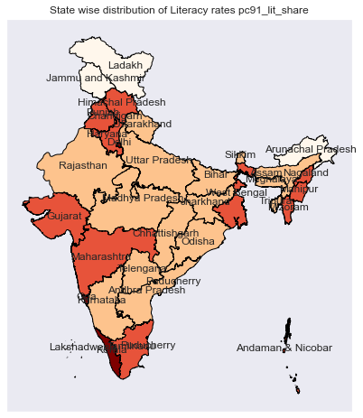

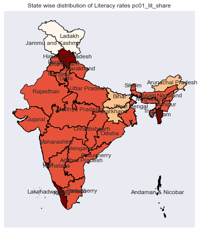

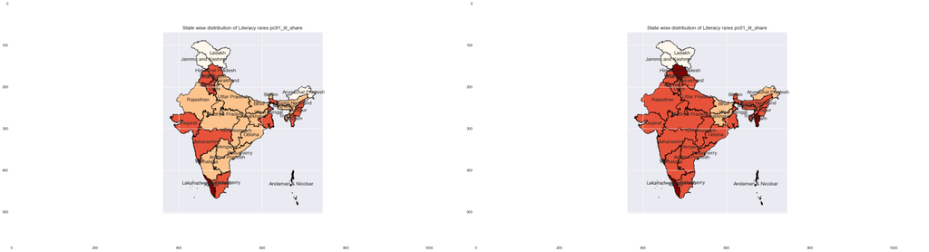

Literacy rates improved in some of India's poorest states of UP, MP, Bihar, and Orissa in the decade post liberalization.

### Explore Statewise variations - Farm / Agricultural employment

|  | state_name | State | pc91_lit_share | pc91_mlit_share | pc91_flit_share | pc01_lit_share | pc01_mlit_share | pc01_flit_share | pc91_urb_share | pc91_m_urb_share | ... | pc91_td_polytech | pc01_td_polytech | pc91_td_medical | pc01_td_medical | pc91_td_engg | pc01_td_engg | pc91_td_law | pc01_td_law | pc91_td_city_dist | pc01_td_city_dist |
| --- | --- | --- | --- | --- | --- | --- | --- | --- | --- | --- | --- | --- | --- | --- | --- | --- | --- | --- | --- | --- | --- |
| 15 | karnataka | Karnataka | 0.39 | 0.49 | 0.28 | 0.51 | 0.61 | 0.42 | 0.78 | 0.51 | ... | 98 | 136 | 30 | 81 | 34 | 46 | 29 | 50 | 53.63 | 57.17 |
| 27 | punjab | Punjab | 0.45 | 0.52 | 0.38 | 0.57 | 0.62 | 0.52 | nan | 0.53 | ... | 15 | 21 | 11 | 11 | 4 | 10 | 1 | 5 | 46.54 | 40.95 |
| 18 | madhya pradesh | Madhya Pradesh | 0.25 | 0.36 | 0.13 | 0.46 | 0.57 | 0.34 | 0.91 | 0.53 | ... | 38 | 52 | 11 | 13 | 13 | 29 | 58 | 63 | 86.98 | 87.22 |
| 3 | arunachal pradesh | Arunachal Pradesh | 0.20 | 0.26 | 0.13 | 0.28 | 0.36 | 0.21 | nan | 0.58 | ... | 1 | 0 | 0 | 0 | 0 | 0 | 0 | 0 | 537.17 | 463.00 |
| 7 | chandigarh | Chandigarh | 0.66 | 0.71 | 0.61 | 0.71 | 0.75 | 0.66 | 0.90 | 0.55 | ... | 2 | 10 | 1 | 25 | 1 | 5 | 0 | 5 | 16.60 | 56.00 |

5 rows × 36 columns

|  | State_Name | geometry | state_name | State | pc91_lit_share | pc91_mlit_share | pc91_flit_share | pc01_lit_share | pc01_mlit_share | pc01_flit_share | ... | pc91_td_polytech | pc01_td_polytech | pc91_td_medical | pc01_td_medical | pc91_td_engg | pc01_td_engg | pc91_td_law | pc01_td_law | pc91_td_city_dist | pc01_td_city_dist |
| --- | --- | --- | --- | --- | --- | --- | --- | --- | --- | --- | --- | --- | --- | --- | --- | --- | --- | --- | --- | --- | --- |
| 21 | Gujarat | POLYGON ((7914780.837 2837315.493, 7915101.603... | gujarat | Gujarat | 0.40 | 0.51 | 0.28 | 0.48 | 0.59 | 0.37 | ... | 26 | 31 | 8 | 8 | 11 | 18 | 29 | 28 | 50.99 | 49.91 |
| 6 | Kerala | POLYGON ((8347733.191 1436381.747, 8347795.745... | kerala | Kerala | 0.77 | 0.80 | 0.73 | 0.79 | 0.82 | 0.76 | ... | 15 | 59 | 7 | 12 | 6 | 41 | 3 | 6 | 59.08 | 54.05 |
| 25 | Assam | POLYGON ((10380499.251 2872443.723, 10380499.2... | assam | Assam | 0.39 | 0.46 | 0.30 | 0.50 | 0.57 | 0.42 | ... | 7 | 9 | 3 | 3 | 3 | 3 | 13 | 14 | 141.34 | 106.12 |
| 9 | Maharashtra | MULTIPOLYGON (((8280974.863 2515416.345, 82809... | maharashtra | Maharashtra | 0.42 | 0.53 | 0.30 | 0.57 | 0.67 | 0.47 | ... | 115 | 140 | 48 | 108 | 54 | 99 | 27 | 30 | 58.08 | 57.27 |
| 2 | Delhi | POLYGON ((8583390.570 3359116.190, 8583476.212... | delhi | Delhi | 0.62 | 0.69 | 0.55 | 0.70 | 0.75 | 0.63 | ... | 19 | 512 | 10 | 0 | 3 | 0 | 0 | 0 | 17.81 | 11.93 |

5 rows × 38 columns

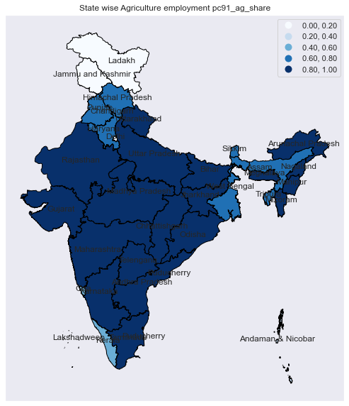

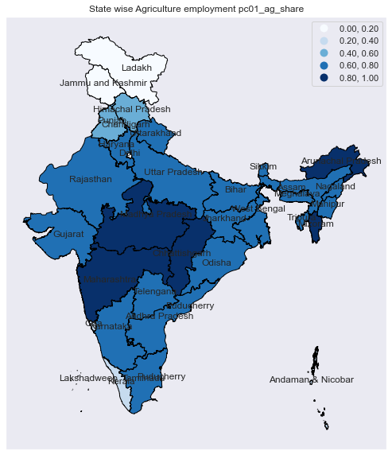

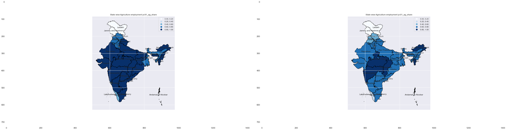

India moved from an economy that was heavily reliant on Agriculture for employment to other industries and services. About 40% of India's workforce is still employed in Agriculture sector.

### Explore Statewise variations - Labor force

|  | state_name | State | pc91_lit_share | pc91_mlit_share | pc91_flit_share | pc01_lit_share | pc01_mlit_share | pc01_flit_share | pc91_urb_share | pc91_m_urb_share | ... | pc91_td_polytech | pc01_td_polytech | pc91_td_medical | pc01_td_medical | pc91_td_engg | pc01_td_engg | pc91_td_law | pc01_td_law | pc91_td_city_dist | pc01_td_city_dist |
| --- | --- | --- | --- | --- | --- | --- | --- | --- | --- | --- | --- | --- | --- | --- | --- | --- | --- | --- | --- | --- | --- |
| 4 | assam | Assam | 0.39 | 0.46 | 0.30 | 0.50 | 0.57 | 0.42 | nan | 0.54 | ... | 7 | 9 | 3 | 3 | 3 | 3 | 13 | 14 | 141.34 | 106.12 |
| 8 | dadra nagar haveli | Dadra Nagar Haveli | 0.23 | 0.32 | 0.13 | 0.35 | 0.46 | 0.22 | nan | 0.55 | ... | 0 | 0 | 0 | 0 | 0 | 0 | 0 | 0 | 80.00 | 80.00 |
| 10 | delhi | Delhi | 0.62 | 0.69 | 0.55 | 0.70 | 0.75 | 0.63 | 0.90 | 0.55 | ... | 19 | 512 | 10 | 0 | 3 | 0 | 0 | 0 | 17.81 | 11.93 |
| 16 | kerala | Kerala | 0.77 | 0.80 | 0.73 | 0.79 | 0.82 | 0.76 | 0.55 | 0.49 | ... | 15 | 59 | 7 | 12 | 6 | 41 | 3 | 6 | 59.08 | 54.05 |
| 9 | daman diu | Daman Diu | 0.57 | 0.67 | 0.46 | 0.65 | 0.74 | 0.53 | nan | 0.49 | ... | 0 | 1 | 0 | 0 | 0 | 0 | 0 | 0 | 116.00 | 116.00 |

5 rows × 36 columns

|  | State_Name | geometry | state_name | State | pc91_lit_share | pc91_mlit_share | pc91_flit_share | pc01_lit_share | pc01_mlit_share | pc01_flit_share | ... | pc91_td_polytech | pc01_td_polytech | pc91_td_medical | pc01_td_medical | pc91_td_engg | pc01_td_engg | pc91_td_law | pc01_td_law | pc91_td_city_dist | pc01_td_city_dist |
| --- | --- | --- | --- | --- | --- | --- | --- | --- | --- | --- | --- | --- | --- | --- | --- | --- | --- | --- | --- | --- | --- |
| 11 | Puducherry | MULTIPOLYGON (((8878474.160 1232399.360, 88784... | puducherry | Puducherry | 0.55 | 0.64 | 0.45 | 0.63 | 0.71 | 0.55 | ... | 2 | 3 | 1 | 3 | 1 | 1 | 1 | 1 | 45.78 | 37.89 |
| 6 | Kerala | POLYGON ((8347733.191 1436381.747, 8347795.745... | kerala | Kerala | 0.77 | 0.80 | 0.73 | 0.79 | 0.82 | 0.76 | ... | 15 | 59 | 7 | 12 | 6 | 41 | 3 | 6 | 59.08 | 54.05 |
| 23 | Uttar Pradesh | POLYGON ((8637489.997 3555885.598, 8637654.287... | uttar pradesh | Uttar Pradesh | 0.30 | 0.43 | 0.16 | 0.45 | 0.56 | 0.32 | ... | 84 | 106 | 16 | 22 | 13 | 31 | 7 | 4 | 58.06 | 47.64 |
| 35 | Jammu and Kashmir | POLYGON ((8550375.654 3927668.327, 8550332.102... | NaN | Jammu and Kashmir | 0.00 | 0.00 | 0.00 | 0.00 | 0.00 | 0.00 | ... | 0 | 0 | 0 | 0 | 0 | 0 | 0 | 0 | 0.00 | 0.00 |
| 15 | Telengana | POLYGON ((8720284.876 2259244.214, 8720421.528... | NaN | Telengana | 0.24 | 0.33 | 0.15 | 0.41 | 0.50 | 0.32 | ... | 96 | 722 | 15 | 148 | 19 | 747 | 5 | 94 | 60.04 | 43.15 |

5 rows × 38 columns

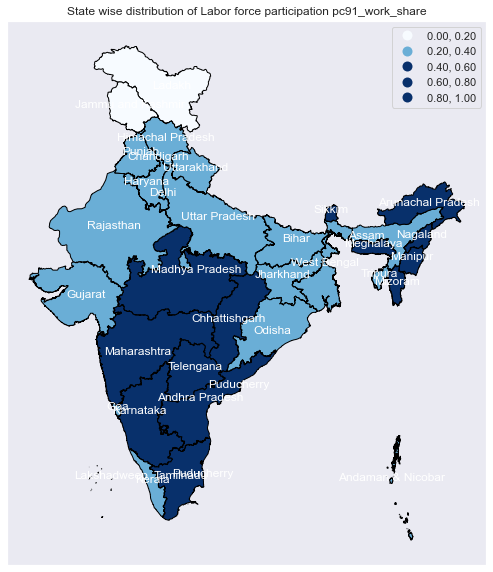

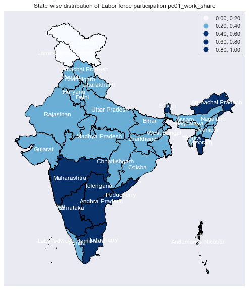

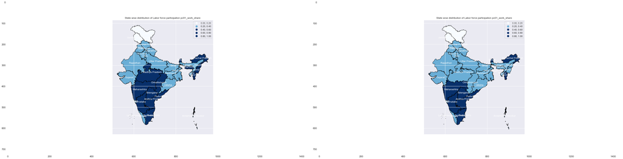

It's interesting to note that in the State of Madhya Pradesh, labor force participation declined in the decade since 1990 Liberalization reforms.